# AllLife Project

### Age vs Mortgage vs Personal Loan

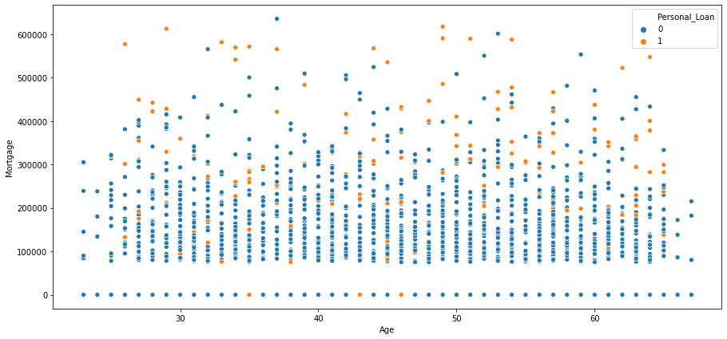

```python
plt.figure(figsize=(15,7)) #Adjust size
sns.scatterplot(data["Age"],data["Mortgage"],hue=data["Personal_Loan"],ci=0) # Plot scatter plot
plt.legend(bbox_to_anchor=(1.00, 1))# Show legend
plt.show()#Display plot
```

### Observations

- As earlier mentioned, there is no correlation between Age and Mortgage.

### Experience vs CCAvg vs Personal_Loan

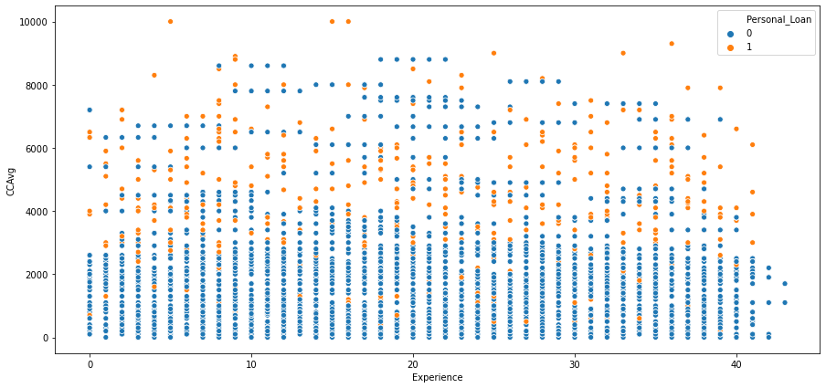

```python
plt.figure(figsize=(15,7)) #Adjust size
sns.scatterplot(data["Experience"],data["CCAvg"],hue=data["Personal_Loan"],ci=0) # Plot scatter plot
plt.legend(bbox_to_anchor=(1.00, 1))# Show legend
plt.show()#Display plot
```

### Income vs CCAvg vs Personal_Loan

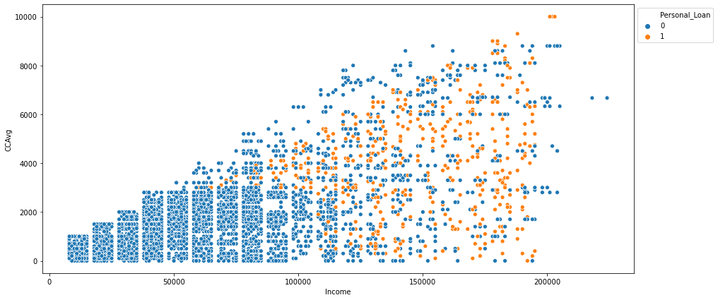

```python
plt.figure(figsize=(15,7)) #Adjust size
sns.scatterplot(data["Income"],data["CCAvg"],hue=data["Personal_Loan"],ci=0) # Plot scatter plot
plt.legend(bbox_to_anchor=(1.00, 1))# Show legend
plt.show()#Display plot
```

### Income vs Mortgage vs Personal_Loan

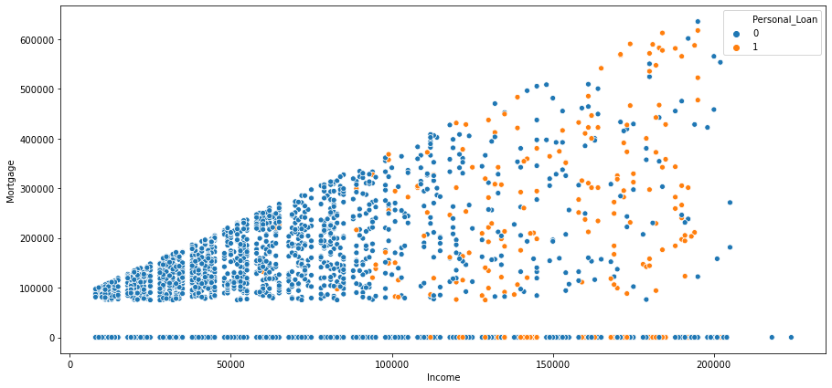

```python
plt.figure(figsize=(15,7)) #Adjust size
sns.scatterplot(data["Income"],data["Mortgage"],hue=data["Personal_Loan"],ci=0) # Plot scatter plot
plt.legend(bbox_to_anchor=(1.00, 1))# Show legend
plt.show()#Display plot
```

### Observations

- We can see that customers with a low income, low average credit card spend and low mortgage spend did not accept the loan offer.

### 2.1 Outliers Treatment

```python
def treat_outliers(df,col):

    Q1=df[col].quantile(0.25) # 25th quantile
    Q3=df[col].quantile(0.75)  # 75th quantile
    IQR=Q3-Q1
    Lower_Whisker = Q1 - 1.5*IQR
    Upper_Whisker = Q3 + 1.5*IQR
    df[col] = np.clip(df[col], Lower_Whisker, Upper_Whisker) # all the values samller than Lower_Whisker will be assigned value of Lower_whisker
                                                            # and all the values above upper_whishker will be assigned value of upper_Whisker
    return df

def treat_outliers_all(df1, col_list):

    for c in col_list:
        treat_outliers(df1,c)

    return df1
```

```python
numerical_col = data.select_dtypes(include=np.number).columns.tolist()# getting list of numerical columns

# Treat outliers
data = treat_outliers_all(data,numerical_col)
```

### 2.2 Split data into dependent and independent variables

```python
data.head()
```

|  | Age | Experience | Income | ZIPCode | Family | CCAvg | Education | Mortgage | Personal_Loan | Securities_Account | CD_Account | Online | CreditCard |
| --- | --- | --- | --- | --- | --- | --- | --- | --- | --- | --- | --- | --- | --- |
| 0 | 25 | 1 | 49000 | 91107 | 4 | 1600.0 | 1 | 0 | 0 | 1 | 0 | 0 | 0 |
| 1 | 45 | 19 | 34000 | 90089 | 3 | 1500.0 | 1 | 0 | 0 | 1 | 0 | 0 | 0 |
| 2 | 39 | 15 | 11000 | 94720 | 1 | 1000.0 | 1 | 0 | 0 | 0 | 0 | 0 | 0 |
| 3 | 35 | 9 | 100000 | 94112 | 1 | 2700.0 | 2 | 0 | 0 | 0 | 0 | 0 | 0 |
| 4 | 35 | 8 | 45000 | 91330 | 4 | 1000.0 | 2 | 0 | 0 | 0 | 0 | 0 | 1 |

```python
#Defining X and y variables
X = data.drop(['Personal_Loan'], axis=1) # Independent Variables
y = data[['Personal_Loan']] # Dependent Variables



print(X.head())
print(y.head())
```

```
   Age  Experience  Income  ZIPCode Family   CCAvg Education  Mortgage  \
0   25           1   49000    91107      4  1600.0         1         0
1   45          19   34000    90089      3  1500.0         1         0
2   39          15   11000    94720      1  1000.0         1         0
3   35           9  100000    94112      1  2700.0         2         0
4   35           8   45000    91330      4  1000.0         2         0

  Securities_Account CD_Account Online CreditCard
0                  1          0      0          0
1                  1          0      0          0
2                  0          0      0          0
3                  0          0      0          0
4                  0          0      0          1
  Personal_Loan
0             0
1             0
2             0
3             0
4             0
```

```python
# Print shape of independent and dependent variable
print(X.shape)
print(y.shape)
```

```
(5000, 12)
(5000, 1)
```

### 2.3 Encoding Categorical Columns

```python
# Get dummies for categorical variables
X = pd.get_dummies(X, columns=['Family','Education','Securities_Account',
       'CD_Account', 'Online', 'CreditCard'], drop_first=True)
X.head()
```

|  | Age | Experience | Income | ZIPCode | CCAvg | Mortgage | Family_2 | Family_3 | Family_4 | Education_2 | Education_3 | Securities_Account_1 | CD_Account_1 | Online_1 | CreditCard_1 |
| --- | --- | --- | --- | --- | --- | --- | --- | --- | --- | --- | --- | --- | --- | --- | --- |
| 0 | 25 | 1 | 49000 | 91107 | 1600.0 | 0 | 0 | 0 | 1 | 0 | 0 | 1 | 0 | 0 | 0 |
| 1 | 45 | 19 | 34000 | 90089 | 1500.0 | 0 | 0 | 1 | 0 | 0 | 0 | 1 | 0 | 0 | 0 |
| 2 | 39 | 15 | 11000 | 94720 | 1000.0 | 0 | 0 | 0 | 0 | 0 | 0 | 0 | 0 | 0 | 0 |
| 3 | 35 | 9 | 100000 | 94112 | 2700.0 | 0 | 0 | 0 | 0 | 1 | 0 | 0 | 0 | 0 | 0 |
| 4 | 35 | 8 | 45000 | 91330 | 1000.0 | 0 | 0 | 0 | 1 | 1 | 0 | 0 | 0 | 0 | 1 |

### 2.4 Split Data into Train and Test

```python
#split the data into train and test
X_train, X_test, y_train, y_test = train_test_split(X, y, test_size=0.3, random_state=42)
```

### 2.5 Model Building (Logistic Regression)

```python
# Initialize Model
logreg = LogisticRegression(solver='newton-cg',max_iter=1000,penalty='none',verbose=True,n_jobs=-1,random_state=0)

# Train the model
logreg.fit(X_train, y_train)

#Predict for train set
pred_train = logreg.predict(X_train)

#Predict for test set
pred_test = logreg.predict(X_test)
```

```
[Parallel(n_jobs=-1)]: Using backend LokyBackend with 4 concurrent workers.
[Parallel(n_jobs=-1)]: Done   1 out of   1 | elapsed:    2.3s finished
```

```python
# Function to plot confusion matrix
def make_confusion_matrix(model,split, y_actual,labels=[1, 0]):

    y_predict = model.predict(split)
    cm=confusion_matrix( y_actual, y_predict, labels=[1, 0])
    df_cm = pd.DataFrame(cm, index = [i for i in ["1","0"]],
                  columns = [i for i in ['Buy loan','Not Buy Loan']])
    group_counts = ["{0:0.0f}".format(value) for value in
                cm.flatten()]
    group_percentages = ["{0:.2%}".format(value) for value in
                         cm.flatten()/np.sum(cm)]
    labels = [f"{v1}\n{v2}" for v1, v2 in
              zip(group_counts,group_percentages)]
    labels = np.asarray(labels).reshape(2,2)
    plt.figure(figsize = (10,7))
    sns.heatmap(df_cm, annot=labels,fmt='')
    plt.ylabel('True label')
    plt.xlabel('Predicted label')
```

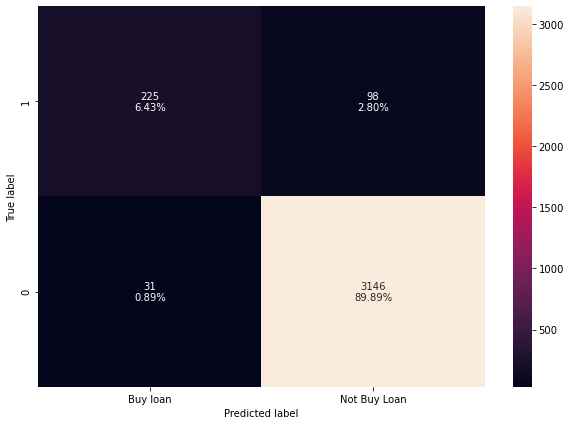

```python
# let us make confusion matrix on train set
make_confusion_matrix(logreg, X_train, y_train)
```

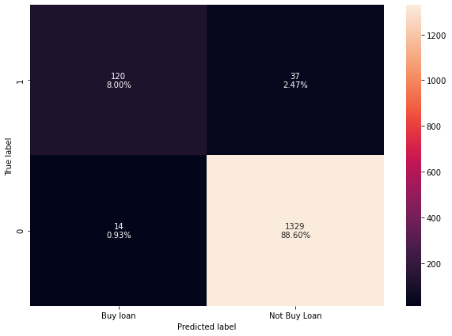

```python
# let us make confusion matrix on test set
make_confusion_matrix(logreg, X_test, y_test)
```

### Observation

- *Positive Class (1)*: Customer bought a loan during the last marketing campaign
- *Negative Class (0)*: Customer did not buy a loan during the last marketing campaign

The confusion matrix on test data allows us test how good our model is on data that the model hasn't seen before. The result of the confusion matrix is as follows:

- True Positive: 120 (8 %) - Model correctly predicted that a customer bought a personal loan hence contributing to revenue.
- False Positive: 14 (0.93%) - Model falsely predicted that a customer will buy a personal loan leading to wastage of resources.
- True Negative: 1329 (88.60%) - Model correctly predicted that a customer will not buy a personal loan hence the nothing is lost.
- False Negative: 37 (2.47%) - Model falsely predicted that a customer will not buy a personal loan leading to revenue being missed and a potential customer being lost.

In deciding which metric to use to evaluate our model, we have to decide which classification has the worst cost implication for the bank. That is, which situation would the bank want to avoid at all cost.

The classification with the worst cost implication for the bank is the False Negative classification. This is because by falsely predicting that a customer will not buy a loan, the potential customer is missed by the sales/marketing team and potential revenue is lost.

- *Recall*: Recall attempts to answer the question "What proportion of actual positives was identified correctly? Formula- TP/(TP + FN)

```python
# Print the Recall score
print("Recall on training set : ",metrics.recall_score(y_train,pred_train))
print("Recall on test set : ",metrics.recall_score(y_test,pred_test))
```

```
Recall on training set :  0.6965944272445821
Recall on test set :  0.7643312101910829
```

### Observation

```python
#Print Specificity Score

tn, fp, fn, tp = confusion_matrix(y_train,pred_train).ravel()
specificity_train = tn / (tn+fp)

tn, fp, fn, tp = confusion_matrix(y_test,pred_test).ravel()
specificity_test = tn / (tn+fp)



print('Specificity on train data:',specificity_train)
print('Specificity on test data:',specificity_test)
```

```
Specificity on train data: 0.9902423670129052
Specificity on test data: 0.9895755770662695
```

### Observation

A Specificity score of 98.9% on test data means that the model correctly classified 99% of customers who did not take up the offer to buy a loan.

```python
#Print False Positive Rate Score

FPR_train = 1 - specificity_train

FPR_test = 1 - specificity_test

print('FPR on train data:',FPR_train)
print('FPR on test data:',FPR_test)
```

```
FPR on train data: 0.009757632987094755
FPR on test data: 0.01042442293373047
```

### Observation

A FPR of 0.01 on test data means that the model misclassified just 1% of customers who did not take up the offer to buy a loan. This score along with the Specificity score is very good as a high Specificity score and low FPR score is what we desire

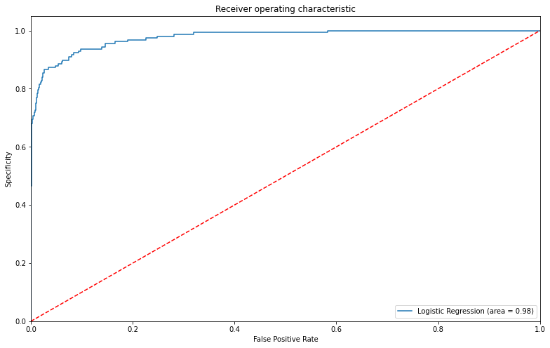

```python
# AUC-ROC Curve
logit_roc_auc = roc_auc_score(y_test, logreg.predict_proba(X_test)[:,1])
fpr, tpr, thresholds = roc_curve(y_test, logreg.predict_proba(X_test)[:,1])
plt.figure(figsize=(13,8))
plt.plot(fpr, tpr, label='Logistic Regression (area = %0.2f)' % logit_roc_auc)
plt.plot([0, 1], [0, 1],'r--')
plt.xlim([0.0, 1.0])
plt.ylim([0.0, 1.05])
plt.xlabel('False Positive Rate')
plt.ylabel('Specificity')
plt.title('Receiver operating characteristic')
plt.legend(loc="lower right")
plt.savefig('Log_ROC')
plt.show()
```

### Optimal Threshold

```python
# The optimal cut off would be where tpr is high and fpr is low
fpr, tpr, thresholds = roc_curve(y_test, logreg.predict_proba(X_test)[:,1])

optimal_idx = np.argmax(tpr - fpr)
optimal_threshold = thresholds[optimal_idx]
print(optimal_threshold)
```

```
0.31231010636307405
```

```python
# Predict using new threshold
y_pred_tr = (logreg.predict_proba(X_train)[:,1]>optimal_threshold).astype(int)
y_pred_ts = (logreg.predict_proba(X_test)[:,1]>optimal_threshold).astype(int)
```

```python
# Function to plot confusion matrix
pred_train = logreg.predict(X_train)

def make_confusion_matrix(y_actual,y_predict,labels=[1, 0]):

    cm=confusion_matrix( y_actual,y_predict, labels=[1, 0])
    df_cm = pd.DataFrame(cm, index = [i for i in ["1","0"]],
                  columns = [i for i in ['Buy Loan','Not Buy Loan']])
    group_counts = ["{0:0.0f}".format(value) for value in
                cm.flatten()]
    group_percentages = ["{0:.2%}".format(value) for value in
                         cm.flatten()/np.sum(cm)]
    labels = [f"{v1}\n{v2}" for v1, v2 in
              zip(group_counts,group_percentages)]
    labels = np.asarray(labels).reshape(2,2)
    plt.figure(figsize = (10,7))
    sns.heatmap(df_cm, annot=labels,fmt='')
    plt.ylabel('True label')
    plt.xlabel('Predicted label')
```

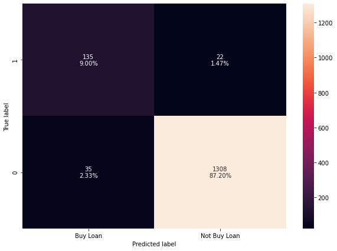

```python
# let us make confusion matrix with optimal threshold on test set
make_confusion_matrix(y_test,y_pred_ts)
```

```python
# Print the Recall score
print("Recall on training set : ",metrics.recall_score(y_train,y_pred_tr))
print("Recall on test set : ",metrics.recall_score(y_test,y_pred_ts))
```

```
Recall on training set :  0.7801857585139319
Recall on test set :  0.8598726114649682
```

```python
# AUC-ROC Curve
logit_roc_auc = roc_auc_score(y_test, y_pred_ts)
print(logit_roc_auc)
```

```
0.916905777065321
```

### Multicolinearity

Multi-colinearity occurs when predictor/independent variables are correlated. This correlation is a problem because predictor variables should be independent. One way of detecting Multi-Colinearity is by using Variation Inflation Factor. It measures the inflation in the variances of the regression parameter estimates due to collinearities that exist among the predictors.

If VIF is 1 then there is no correlation among the response and the remaining predictor variables. Whereas if VIF exceeds 5 or is close to exceeding 5, we say there is moderate VIF and if it is 10 or exceeding 10, it shows signs of high multi-collinearity.

### Treating Multicollinearity

- To remove multicollinearity
  1. Drop every column one by one, that has VIF score greater than 10.
  2. Check the VIF Scores again
  3. Continue till you get all VIF scores under 10

```python
# dataframe with numerical column only
num_feature_set = X.copy()
from statsmodels.tools.tools import add_constant
num_feature_set = add_constant(num_feature_set)
```

```python
# Check for Multicollinearity
vif_series1 = pd.Series([variance_inflation_factor(num_feature_set.values,i) for i in range(num_feature_set.shape[1])],index=num_feature_set.columns)
print('Series before feature selection: \n\n{}\n'.format(vif_series1))
```

```
Series before feature selection:

const                   3280.612642
Age                       93.614154
Experience                93.454806
Income                     1.824076
ZIPCode                    1.005597
CCAvg                      1.700444
Mortgage                   1.023630
Family_2                   1.400268
Family_3                   1.385735
Family_4                   1.427566
Education_2                1.293937
Education_3                1.332375
Securities_Account_1       1.137943
CD_Account_1               1.336024
Online_1                   1.040846
CreditCard_1               1.110297
dtype: float64
```

```python
# we drop the one with the highest vif values
num_feature_set = num_feature_set.drop("Age", axis=1)
vif_series2 = pd.Series([variance_inflation_factor(num_feature_set.values,i) for i in range(num_feature_set.shape[1])],index=num_feature_set.columns)
print('Series before feature selection: \n\n{}\n'.format(vif_series2))
```

```
Series before feature selection:

const                   2838.456966
Experience                 1.010555
Income                     1.819235
ZIPCode                    1.005596
CCAvg                      1.695639
Mortgage                   1.023630
Family_2                   1.400251
Family_3                   1.378913
Family_4                   1.427273
Education_2                1.279031
Education_3                1.248820
Securities_Account_1       1.137647
CD_Account_1               1.335061
Online_1                   1.040777
CreditCard_1               1.110297
dtype: float64
```

```python
# Train Test Split
X_train, X_test, y_train, y_test = train_test_split(num_feature_set, y, test_size=0.30, random_state=42)
```

```python
# The optimal cut off would be where tpr is high and fpr is low
opfpr, optpr, opthresholds = roc_curve(y_test, logreg.predict_proba(X_test)[:,1])

optimal_idx = np.argmax(optpr - opfpr)
optimal_threshold = thresholds[optimal_idx]
print(optimal_threshold)
```

```
0.13001706111616032
```

```python
# Predict using new threshold
y_pred_tr = (logreg.predict_proba(X_train)[:,1]>optimal_threshold).astype(int)
y_pred_ts = (logreg.predict_proba(X_test)[:,1]>optimal_threshold).astype(int)
```

```python
# Function to plot confusion matrix
pred_train = logreg.predict(X_train)

def make_confusion_matrix(y_actual,y_predict,labels=[1, 0]):

    cm=confusion_matrix( y_actual,y_predict, labels=[1, 0])
    df_cm = pd.DataFrame(cm, index = [i for i in ["1","0"]],
                  columns = [i for i in ['Buy Loan','Not Buy Loan']])
    group_counts = ["{0:0.0f}".format(value) for value in
                cm.flatten()]
    group_percentages = ["{0:.2%}".format(value) for value in
                         cm.flatten()/np.sum(cm)]
    labels = [f"{v1}\n{v2}" for v1, v2 in
              zip(group_counts,group_percentages)]
    labels = np.asarray(labels).reshape(2,2)
    plt.figure(figsize = (10,7))
    sns.heatmap(df_cm, annot=labels,fmt='')
    plt.ylabel('True label')
    plt.xlabel('Predicted label')
```

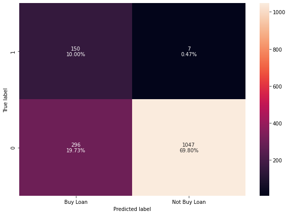

```python
# let us make confusion matrix with optimal threshold on test set
make_confusion_matrix(y_test,y_pred_ts)
```

```python
# Print the Recall score
print("Recall on training set : ",metrics.recall_score(y_train,y_pred_tr))
print("Recall on test set : ",metrics.recall_score(y_test,y_pred_ts))
```

```
Recall on training set :  0.9597523219814241
Recall on test set :  0.9554140127388535
```

```python
# AUC-ROC Curve
logit_roc_auc = roc_auc_score(y_test, y_pred_ts)
print(logit_roc_auc)
```

```
0.8675059639271335
```

```python
# DataFrame to compare results
comparison_frame = pd.DataFrame({'Model':['Initial Logistic Regression Model',
                                          'Optimal threshold - Logistic Regression Model',
                                          'No Multicollinearity- Logistic Regression Model',
                                         ], 'Train_Recall':[0.70,0.78,0.95], 'Test_Recall':[0.76,0.86,0.96],
                                 'True_Positives':['8%', '9%','10%'],'False_Positives':['0.93%', '2.3%','19.73%'],
                                 'True_Negatives':['88.60%', '87.20%','69.80%'],'False_Negatives':['2.47%', '1.47%','0.47%'],
                                 'AUC ROC':[0.98,0.92,0.87]})

comparison_frame
```

|  | Model | Train_Recall | Test_Recall | True_Positives | False_Positives | True_Negatives | False_Negatives | AUC ROC |
| --- | --- | --- | --- | --- | --- | --- | --- | --- |
| 0 | Initial Logistic Regression Model | 0.70 | 0.76 | 8% | 0.93% | 88.60% | 2.47% | 0.98 |
| 1 | Optimal threshold - Logistic Regression Model | 0.78 | 0.86 | 9% | 2.3% | 87.20% | 1.47% | 0.92 |
| 2 | No Multicollinearity- Logistic Regression Model | 0.95 | 0.96 | 10% | 19.73% | 69.80% | 0.47% | 0.87 |

### Overall Model Observations

This logistic regression model performed well on test data.

One problem with this model is that our positive and negative classes have an imbalanced class distribution. This has led to a biased model to the majority side. As such, despite returning very good results, this model may not be the most accurate. We will train a decision tree model and attempt to manage this problem of imbalance. Decision trees provide more flexibility allow us to better manage problems of imbalance. To do this, we will use class weights on our Decision Tree model which would add a penalty to misclassifying the under-represented class in order to reduce false positives or false negatives. This would reduce bias on the imbalanced data without “over-training” on the under-represented samples.

### 2.6 Split Data into Train and Test

```python
X.head()
```

|  | Age | Experience | Income | ZIPCode | CCAvg | Mortgage | Family_2 | Family_3 | Family_4 | Education_2 | Education_3 | Securities_Account_1 | CD_Account_1 | Online_1 | CreditCard_1 |
| --- | --- | --- | --- | --- | --- | --- | --- | --- | --- | --- | --- | --- | --- | --- | --- |
| 0 | 25 | 1 | 49000 | 91107 | 1600.0 | 0 | 0 | 0 | 1 | 0 | 0 | 1 | 0 | 0 | 0 |
| 1 | 45 | 19 | 34000 | 90089 | 1500.0 | 0 | 0 | 1 | 0 | 0 | 0 | 1 | 0 | 0 | 0 |
| 2 | 39 | 15 | 11000 | 94720 | 1000.0 | 0 | 0 | 0 | 0 | 0 | 0 | 0 | 0 | 0 | 0 |
| 3 | 35 | 9 | 100000 | 94112 | 2700.0 | 0 | 0 | 0 | 0 | 1 | 0 | 0 | 0 | 0 | 0 |
| 4 | 35 | 8 | 45000 | 91330 | 1000.0 | 0 | 0 | 0 | 1 | 1 | 0 | 0 | 0 | 0 | 1 |

```python
#split the data into train and test
dt_X_train, dt_X_test, dt_y_train, dt_y_test = train_test_split(X, y, test_size=0.3, random_state=42)
```

### 2.7 Model Building (Decision Trees)

```python
# Initialize Model
dt = DecisionTreeClassifier(criterion='gini',class_weight={0:0.096,1:0.904},random_state=1)

# Train the model
dt.fit(dt_X_train, dt_y_train)

#Predict for train set
dt_pred_train = dt.predict(dt_X_train)

#Predict for test set
dt_pred_test = dt.predict(dt_X_test)
```

```python
# Function to plot Confusion Matrix
def make_confusion_matrix(model,split, y_actual,labels=[1, 0]):

    y_predict = model.predict(split)
    cm=confusion_matrix( y_actual, y_predict, labels=[1, 0])
    df_cm = pd.DataFrame(cm, index = [i for i in ["1","0"]],
                  columns = [i for i in ['Buy loan','Not Buy Loan']])
    group_counts = ["{0:0.0f}".format(value) for value in
                cm.flatten()]
    group_percentages = ["{0:.2%}".format(value) for value in
                         cm.flatten()/np.sum(cm)]
    labels = [f"{v1}\n{v2}" for v1, v2 in
              zip(group_counts,group_percentages)]
    labels = np.asarray(labels).reshape(2,2)
    plt.figure(figsize = (10,7))
    sns.heatmap(df_cm, annot=labels,fmt='')
    plt.ylabel('True label')
    plt.xlabel('Predicted label')
```

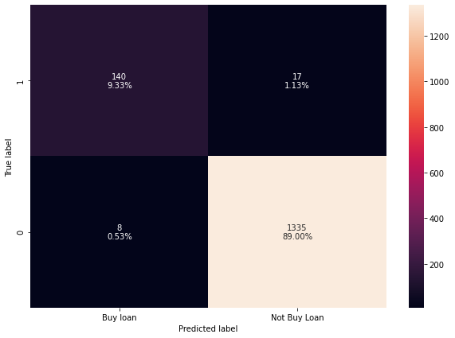

```python
# let us make confusion matrix on test set
make_confusion_matrix(dt, dt_X_test, dt_y_test)
```

### Observation

- *Positive Class (1)*: Customer bought a loan during the last marketing campaign
- *Negative Class (0)*: Customer did not buy a loan during the last marketing campaign

The confusion matrix on test data allows us test how good our model is on data that the model hasn't seen before. The result of the confusion matrix is as follows:

- True Positive: 140 (9.33%) - Model correctly predicted that a customer bought a personal loan hence contributing to revenue.
- False Positive: 8 (0.53%) - Model falsely predicted that a customer will buy a personal loan leading to wastage of resources.
- True Negative: 1335 (89%) - Model correctly predicted that a customer will not buy a personal loan hence the nothing is lost.
- False Negative: 17 (1.13%) - Model falsely predicted that a customer will not buy a personal loan leading to revenue being missed and a potential customer being lost.

In deciding which metric to use to evaluate our model, we have to decide which classification has the worst cost implication for the bank. That is, which situation would the bank want to avoid at all cost.

The classification with the worst cost implication for the bank is the False Negative classification. This is because by falsely predicting that a customer will not buy a loan, the potential customer is missed by the sales/marketing team and potential revenue is lost.

As we care about the False Negative, we would be using Recall to evaluate the accuracy of this model.

- *Recall*: Recall attempts to answer the question "What proportion of actual positives was identified correctly? Formula- TP/(TP + FN)

```python
# Print the Recall score
print("Recall on training set : ",metrics.recall_score(dt_y_train,dt_pred_train))
print("Recall on test set : ",metrics.recall_score(dt_y_test,dt_pred_test))
```

```
Recall on training set :  1.0
Recall on test set :  0.89171974522293
```

### Visualizing the Decision Tree

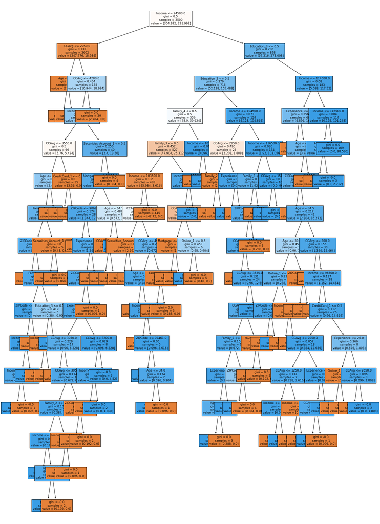

```python
# Visualize Decision Tree
plt.figure(figsize=(20,30))
out = tree.plot_tree(dt,feature_names=dt_X_train.columns,filled=True,fontsize=9,node_ids=False,class_names=None,)
#below code will add arrows to the decision tree split if they are missing
for o in out:
    arrow = o.arrow_patch
    if arrow is not None:
        arrow.set_edgecolor('black')
        arrow.set_linewidth(1)
plt.show()
```

### Reducing Overfitting with Cost Complexity Pruning

Decision Trees are notorious for being overfit to the Training Data. This especially occurs when a tree is left to grow fully. When a tree grows fully, the data is split to its smallest component part and when this is done, information information along with the noise in the data will be captured.

There are alot of parameters, like max_depth and min_samples that are designed to reduce overfitting by stopping the tree from growing fully using set bounds/hyperparameters. This process is called Pre-prunning. The problem with Pre-prunning is that because youre setting the values beforehand, you dont know if the values you did not choose would have been beneficial to the model. As such, we can use another method called Post-prunning.

This involves pruning the tree after it has grown fully. We can do this using Cost Complexity Pruning. Pruning a tree with Cost Complexity Pruning can simplify the whole process of finding a smaller tree that improves the accuracy with the Testing Dataset.

Pruning a decision tree is all about finding the right value for the pruning parameter, alpha, which controls how little or how much pruning happens. One way to find the optimal value for alpha is to plot the accuracy of the tree as a function of different levels. This will be done for both the training and testing set.

Firstly, we will extract the different values of alpha that are available for this tree and build a pruned tree for each value of alpha

```python
clf = DecisionTreeClassifier(random_state=1,class_weight={0:0.096,1:0.904}) # Initialze Decision Tree
path = clf.cost_complexity_pruning_path(dt_X_train, dt_y_train) # Determine values for alpha
ccp_alphas, impurities = path.ccp_alphas, path.impurities # Extract different values for alpha and impurities
pd.DataFrame(path) # Create dataframe of alpha values and impurities
```

|  | ccp_alphas | impurities |
| --- | --- | --- |
| 0 | 0.000000e+00 | -2.098597e-16 |
| 1 | 2.499464e-19 | -2.096098e-16 |
| 2 | 5.355993e-19 | -2.090742e-16 |
| 3 | 5.355993e-19 | -2.085386e-16 |
| 4 | 6.070126e-19 | -2.079316e-16 |
| 5 | 6.248659e-19 | -2.073067e-16 |
| 6 | 7.141324e-19 | -2.065926e-16 |
| 7 | 1.071199e-18 | -2.055214e-16 |
| 8 | 1.071199e-18 | -2.044502e-16 |
| 9 | 1.071199e-18 | -2.033790e-16 |
| 10 | 1.071199e-18 | -2.023078e-16 |
| 11 | 1.428265e-18 | -2.008795e-16 |
| 12 | 1.428265e-18 | -1.994512e-16 |
| 13 | 1.571091e-18 | -1.978801e-16 |
| 14 | 2.624437e-18 | -1.952557e-16 |
| 15 | 3.856315e-18 | -1.913994e-16 |
| 16 | 5.043560e-17 | -1.409638e-16 |
| 17 | 6.606618e-16 | 5.196980e-16 |
| 18 | 1.566495e-04 | 3.132990e-04 |
| 19 | 1.574640e-04 | 6.282269e-04 |
| 20 | 1.584052e-04 | 9.450373e-04 |
| 21 | 1.591186e-04 | 1.263274e-03 |
| 22 | 2.901868e-04 | 1.843648e-03 |
| 23 | 3.020955e-04 | 2.145744e-03 |
| 24 | 3.054007e-04 | 2.451144e-03 |
| 25 | 3.054007e-04 | 2.756545e-03 |
| 26 | 3.054007e-04 | 3.061946e-03 |
| 27 | 3.101153e-04 | 3.992291e-03 |
| 28 | 3.121457e-04 | 4.616583e-03 |
| 29 | 3.204015e-04 | 4.936984e-03 |
| 30 | 3.210079e-04 | 5.579000e-03 |
| 31 | 4.470398e-04 | 8.708279e-03 |
| 32 | 4.614246e-04 | 9.631128e-03 |
| 33 | 4.620388e-04 | 1.101724e-02 |
| 34 | 5.166401e-04 | 1.308381e-02 |
| 35 | 5.268745e-04 | 1.361068e-02 |
| 36 | 6.414587e-04 | 1.617651e-02 |
| 37 | 7.997598e-04 | 1.777603e-02 |
| 38 | 8.628785e-04 | 1.950179e-02 |
| 39 | 9.046679e-04 | 2.131113e-02 |
| 40 | 9.047032e-04 | 2.312053e-02 |
| 41 | 9.515445e-04 | 2.407208e-02 |
| 42 | 9.671412e-04 | 2.503922e-02 |
| 43 | 1.004826e-03 | 2.604404e-02 |
| 44 | 1.029538e-03 | 2.810312e-02 |
| 45 | 1.180161e-03 | 2.928328e-02 |
| 46 | 2.390730e-03 | 3.167401e-02 |
| 47 | 2.440058e-03 | 3.655413e-02 |
| 48 | 3.024805e-03 | 3.957893e-02 |
| 49 | 3.087618e-03 | 4.266655e-02 |
| 50 | 3.356955e-03 | 4.938046e-02 |
| 51 | 3.660840e-03 | 5.304130e-02 |
| 52 | 3.848717e-03 | 5.689002e-02 |
| 53 | 3.850304e-03 | 6.074032e-02 |
| 54 | 4.137714e-03 | 6.487803e-02 |
| 55 | 5.483846e-03 | 7.036188e-02 |
| 56 | 2.784169e-02 | 1.817286e-01 |
| 57 | 3.581663e-02 | 2.175453e-01 |
| 58 | 2.822176e-01 | 4.997629e-01 |

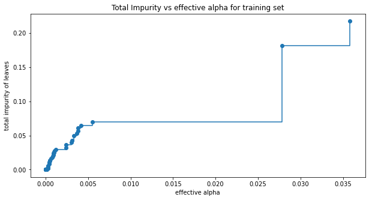

```python
# Visualize relationship between alpha and impurity
fig, ax = plt.subplots(figsize=(10,5))
ax.plot(ccp_alphas[:-1], impurities[:-1], marker='o', drawstyle="steps-post")
ax.set_xlabel("effective alpha")
ax.set_ylabel("total impurity of leaves")
ax.set_title("Total Impurity vs effective alpha for training set")
plt.show()
```

### Observation

Here we can see that as alpha increases, total impurity also increases. This is logical because as the tree becomes less complex, it also becomes more impure

Next, we train a decision tree using the effective alphas. The last value in `ccp_alphas` is the alpha value that prunes the whole tree, leaving the tree, `clfs[-1]`, with one node.

```python
clfs = [] # Create an array that we will put decision trees into

# Create one decision tree per value for alpha and store it in the array
for ccp_alpha in ccp_alphas:
    clf = DecisionTreeClassifier(random_state=1, ccp_alpha=ccp_alpha,class_weight={0:0.096,1:0.904}) #Instantiate model
    clf.fit(dt_X_train, dt_y_train) # Fit model
    clfs.append(clf) # Append decision trees into clfs array
print("Number of nodes in the last tree is: {} with ccp_alpha: {}".format(
      clfs[-1].tree_.node_count, ccp_alphas[-1]))
```

```
Number of nodes in the last tree is: 1 with ccp_alpha: 0.2822176495528033
```

For the remainder, we remove the last element in `clfs` and `ccp_alphas`, because it is the trivial tree with only one node. Here we show that the number of nodes and tree depth decreases as alpha increases.

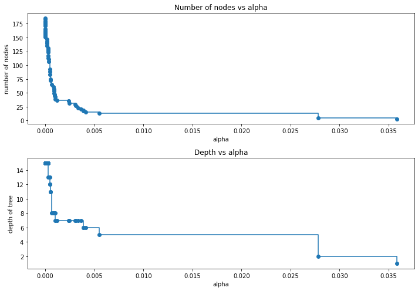

```python
clfs = clfs[:-1] # Remove last decision tree element in clfs array
ccp_alphas = ccp_alphas[:-1] # Remove last alpha as it has just one node

# Plot number of nodes vs alpha and depth vs alpha
node_counts = [clf.tree_.node_count for clf in clfs]
depth = [clf.tree_.max_depth for clf in clfs]
fig, ax = plt.subplots(2, 1,figsize=(10,7))
ax[0].plot(ccp_alphas, node_counts, marker='o', drawstyle="steps-post")
ax[0].set_xlabel("alpha")
ax[0].set_ylabel("number of nodes")
ax[0].set_title("Number of nodes vs alpha")
ax[1].plot(ccp_alphas, depth, marker='o', drawstyle="steps-post")
ax[1].set_xlabel("alpha")
ax[1].set_ylabel("depth of tree")
ax[1].set_title("Depth vs alpha")
fig.tight_layout()
```

For every decision tree in clfs we get the prediction and recall scores on both the train and test sets and then store the recall scores in an array called recall_train and recall_test respectively. The purpose of this is to visualize alpha and recall for each tree.

```python
# Recall for all decision trees in train set
recall_train=[]
for clf in clfs:
    pred_train3=clf.predict(dt_X_train)
    values_train=metrics.recall_score(dt_y_train,pred_train3)
    recall_train.append(values_train)
```

```python
# Recall for all decision trees in test set
recall_test=[]
for clf in clfs:
    pred_test3=clf.predict(dt_X_test)
    values_test=metrics.recall_score(dt_y_test,pred_test3)
    recall_test.append(values_test)
```

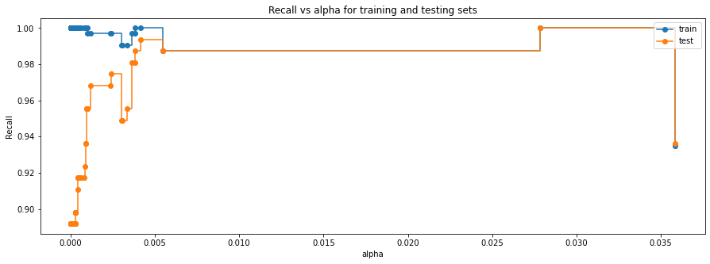

```python
# Plot Recall vs Alpha for training and testing sets
fig, ax = plt.subplots(figsize=(15,5))
ax.set_xlabel("alpha")
ax.set_ylabel("Recall")
ax.set_title("Recall vs alpha for training and testing sets")
ax.plot(ccp_alphas, recall_train, marker='o', label="train",
        drawstyle="steps-post",)
ax.plot(ccp_alphas, recall_test, marker='o', label="test",
        drawstyle="steps-post")
ax.legend()
plt.show()
```

### Observations

```python
# creating the model where we get highest train and test recall
index_best_model = np.argmax(recall_test)
best_model = clfs[index_best_model]
print(best_model)
```

```
DecisionTreeClassifier(ccp_alpha=0.027841685066698152,
                       class_weight={0: 0.096, 1: 0.904}, random_state=1)
```

```python
# Fit model with the best recall score on train set
best_model.fit(dt_X_train, dt_y_train)
```

```
DecisionTreeClassifier(ccp_alpha=0.027841685066698152,
                       class_weight={0: 0.096, 1: 0.904}, random_state=1)
```

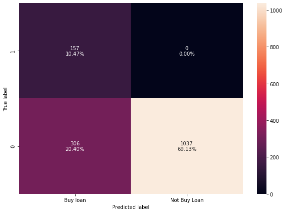

```python
# Visualize confusion matrix of model with the best recall score on test set
make_confusion_matrix(best_model, dt_X_test, dt_y_test)
```

```python
##  Function to calculate recall score
def get_recall_score(model):

    dt_pred_train = model.predict(dt_X_train)
    dt_pred_test = model.predict(dt_X_test)
    print("Recall on training set : ",metrics.recall_score(dt_y_train,dt_pred_train))
    print("Recall on test set : ",metrics.recall_score(dt_y_test,dt_pred_test))
```

```python
# Check recall score
get_recall_score(best_model)
```

```
Recall on training set :  1.0
Recall on test set :  1.0
```

### Visualizing the Decision Tree

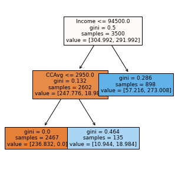

```python
# Visualize Decision Tree
plt.figure(figsize=(5,5))

out = tree.plot_tree(best_model,feature_names=dt_X_train.columns,filled=True,fontsize=9,node_ids=False,class_names=None)
for o in out:
    arrow = o.arrow_patch
    if arrow is not None:
        arrow.set_edgecolor('black')
        arrow.set_linewidth(1)
plt.show()
```

### Observations

From the confusion matrix, we can see that our false negatives are at zero which means that our recall will be at the highest possible position. This however may indicate that our model is underfit meaning that it is not capturing as much information as it can. We will go ahead and fit the model with alpha at 0.006 as this is the model where we no longer have an overfitting problem.

```python
# Train model with 0.006 alpha
best_model2 = DecisionTreeClassifier(ccp_alpha=0.006,
                       class_weight={0:0.096,1:0.904}, random_state=1)
best_model2.fit(dt_X_train, dt_y_train)
```

```
DecisionTreeClassifier(ccp_alpha=0.006, class_weight={0: 0.096, 1: 0.904},
                       random_state=1)
```

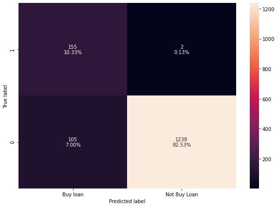

```python
# Plot Confusion Matrix
make_confusion_matrix(best_model2, dt_X_test, dt_y_test)
```

```python
# Check recall score
get_recall_score(best_model2)
```

```
Recall on training set :  0.9876160990712074
Recall on test set :  0.9872611464968153
```

### Visualizing the Decision Tree

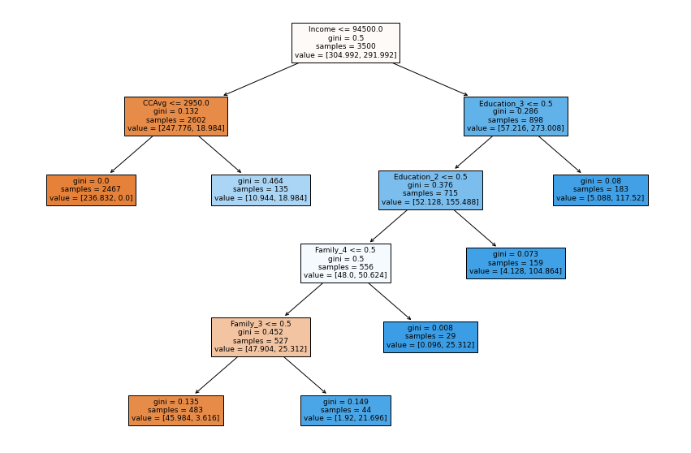

```python
# Visualize Decision Tree
plt.figure(figsize=(15,10))

out = tree.plot_tree(best_model2,feature_names=dt_X_train.columns,filled=True,fontsize=9,node_ids=False,class_names=None)
for o in out:
    arrow = o.arrow_patch
    if arrow is not None:
        arrow.set_edgecolor('black')
        arrow.set_linewidth(1)
plt.show()
```

### Select Important Features

```python
# importance of features in the tree building ( The importance of a feature is computed as the
#(normalized) total reduction of the 'criterion' brought by that feature. It is also known as the Gini importance )

print (pd.DataFrame(best_model2.feature_importances_, columns = ["Importance"], index = dt_X_train.columns).sort_values(by = 'Importance', ascending = False))
```

```
                      Importance
Income                  0.657236
Family_3                0.089293
CCAvg                   0.083411
Education_2             0.081371
Family_4                0.062273
Education_3             0.026417
Age                     0.000000
Experience              0.000000
ZIPCode                 0.000000
Mortgage                0.000000
Family_2                0.000000
Securities_Account_1    0.000000
CD_Account_1            0.000000
Online_1                0.000000
CreditCard_1            0.000000
```

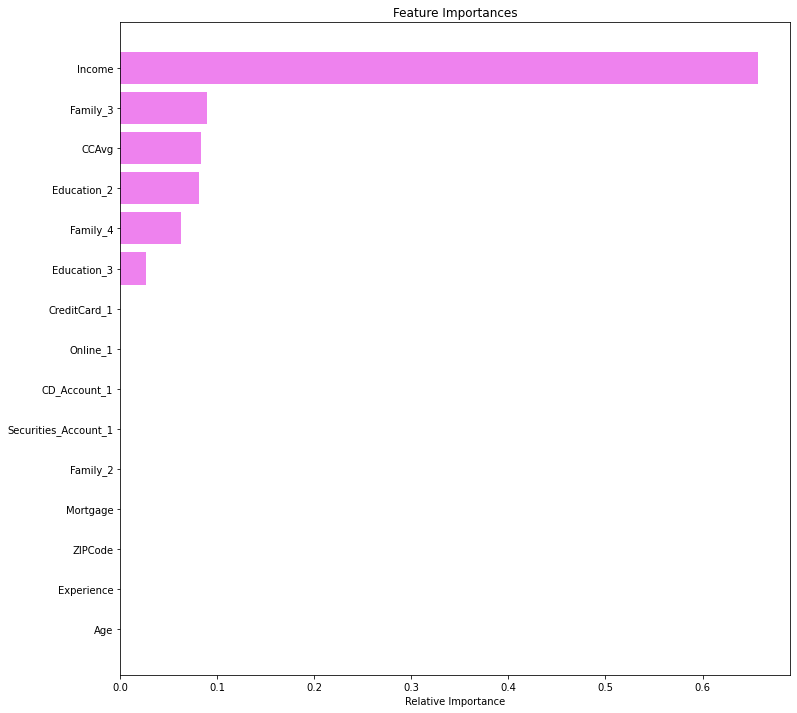

```python
# Visualize important features to our model
importances = best_model2.feature_importances_
indices = np.argsort(importances)

plt.figure(figsize=(12,12))
plt.title('Feature Importances')
plt.barh(range(len(indices)), importances[indices], color='violet', align='center')
plt.yticks(range(len(indices)), [X.columns[i] for i in indices])
plt.xlabel('Relative Importance')
plt.show()
```

```python
cols_to_drop = ['CreditCard_1','Online_1','CD_Account_1','Securities_Account_1','Family_2',
                'Mortgage','ZIPCode','Experience','Age']

# we drop features that offer no benefit to our model
dt_X_train1 = dt_X_train.drop(cols_to_drop, axis=1)
```

```python
# Final decision tree X_train and X_test
dt_X_train_final = dt_X_train1[dt_X_train1.columns]
dt_X_test_final = dt_X_test[dt_X_train_final.columns]
```

```python
best_model3 = DecisionTreeClassifier(ccp_alpha=0.006, class_weight={0:0.096,1:0.904}, random_state=1) # Initialize final model

best_model3.fit(dt_X_train_final, dt_y_train) # Fit final model
```

```
DecisionTreeClassifier(ccp_alpha=0.006, class_weight={0: 0.096, 1: 0.904},
                       random_state=1)
```

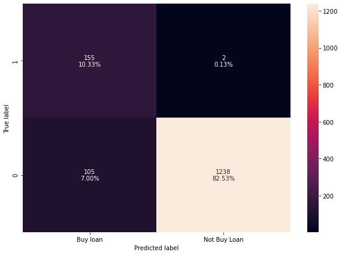

```python
make_confusion_matrix(best_model3, dt_X_test_final, dt_y_test)
```

```python
##  Function to calculate recall score
def get_recall_score(model):

    dt_pred_train = model.predict(dt_X_train_final)
    dt_pred_test = model.predict(dt_X_test_final)
    print("Recall on training set : ",metrics.recall_score(dt_y_train,dt_pred_train))
    print("Recall on test set : ",metrics.recall_score(dt_y_test,dt_pred_test))
```

```python
# Get best_model3 recall scores on train and test sets
get_recall_score(best_model3)
```

```
Recall on training set :  0.9876160990712074
Recall on test set :  0.9872611464968153
```

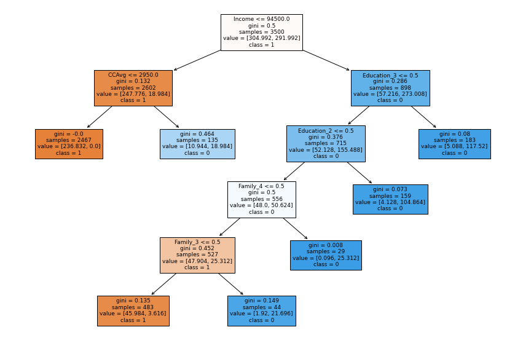

```python
# Visualize Decision Tree
plt.figure(figsize=(15,10))

out = tree.plot_tree(best_model3,feature_names=dt_X_train_final.columns,filled=True,fontsize=9,node_ids=False,
                     class_names=['1','0'])
for o in out:
    arrow = o.arrow_patch
    if arrow is not None:
        arrow.set_edgecolor('black')
        arrow.set_linewidth(1)
plt.show()
```

```python
# Compare decision trees results before and after pruning
dt_comparison_frame = pd.DataFrame({'Model':['Initial decision tree model', 'Decision tree with post-pruning'],
                                 'Train_Recall':[1,0.9876], 'Test_Recall':[0.8917,0.9873],
                                 'True_Positives':['9.33%', '10.33%'],'False_Positives':['0.53%', '7%'],
                                 'True_Negatives':['89%', '82.53%'],'False_Negatives':['1.13%', '0.13%']})
dt_comparison_frame
```

|  | Model | Train_Recall | Test_Recall | True_Positives | False_Positives | True_Negatives | False_Negatives |
| --- | --- | --- | --- | --- | --- | --- | --- |
| 0 | Initial decision tree model | 1.0000 | 0.8917 | 9.33% | 0.53% | 89% | 1.13% |
| 1 | Decision tree with post-pruning | 0.9876 | 0.9873 | 10.33% | 7% | 82.53% | 0.13% |

### Observations

At 0.006 alpha, our recall score is 0.9873. This indicates that this model accurately identified 99% of customers who bought a loan during the last marketing campaign. With a full tree, 89% of customers who bought a loan were accurately classified. This means that our pruned model had a 10% gain on the full tree.

The following columns were the most significant columns in developing this tree. 'Income', 'CCAvg', 'Family_3', 'Family_4', 'Education_2','Education_3'.

- True Positive: 155 (10.33%) - Model correctly predicted that a customer bought a personal loan hence contributing to revenue.
- False Positive: 105 (7%) - Model falsely predicted that a customer will buy a personal loan leading to wastage of resources.
- True Negative: 1238 (82.53%) - Model correctly predicted that a customer will not buy a personal loan hence the nothing is lost.
- False Negative: 2 (0.13%) - Model falsely predicted that a customer will not buy a personal loan leading to revenue being missed and a potential customer being lost.

From our confusion matrix, we can see that there are some misclassifications. 7% of customers were classified as positive when they were actually negative and 0.13% were classified as negative when they were positive. We will delve deeper and analyze these misclassified datapoints

### 2.8 Misclassification Analysis

```python
# Copy dt_X_test_final and save in new DataFrame
m_class = dt_X_test.copy()
```

```python
# Add Actual and Predicted values to m_class dataframe
m_class['Actual'] = y_test.values.flatten()
m_class['Predicted'] = best_model3.predict(dt_X_test_final).flatten()
```

```python
# Add Missclassified column
conditions = [
    (m_class['Actual'] == 0) & (m_class['Predicted'] == 0),
    (m_class['Actual'] == 1) & (m_class['Predicted'] == 1),
    (m_class['Actual'] == 0) & (m_class['Predicted'] == 1),
    (m_class['Actual'] == 1) & (m_class['Predicted'] == 0)]
choices = [1, 1, 0, 0]
m_class['Class'] = np.select(conditions, choices)
```

```python
# Convert to category dtype
m_class['Class'] = m_class['Class'].astype('category')
```

```python
# Count of Class datapoint
m_class['Class'].value_counts()
```

```
1    1393
0     107
Name: Class, dtype: int64
```

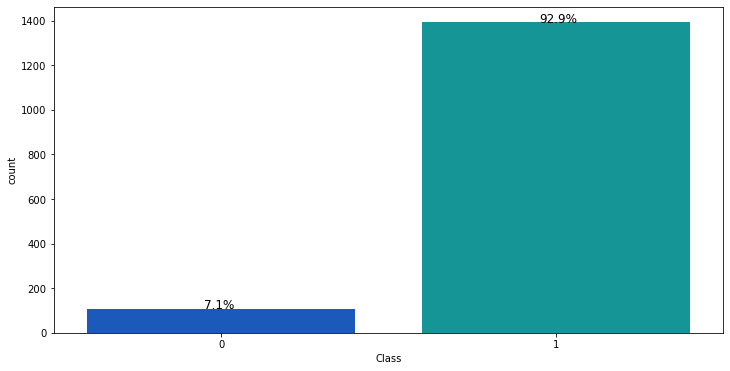

```python
# Plot barplot for Class Variable
plt.figure(figsize=(12,6)) # set the figure size
ax = sns.countplot(m_class['Class'],palette='winter')
perc_on_bar(ax,m_class['Class'])
```

### Observation

- There are 107 (7.1%) and 1393(92.9%) misclassified and accurately classified datapoints respectively. This suggests that we have a good model as very few datapoints are misclassified

```python
# Rows that were classified as Negative when they were actually positive
fn_rows = m_class[(m_class['Class'] == 0) & (m_class['Actual'] == 1)]
fn_rows
```

|  | Age | Experience | Income | ZIPCode | CCAvg | Mortgage | Family_2 | Family_3 | Family_4 | Education_2 | Education_3 | Securities_Account_1 | CD_Account_1 | Online_1 | CreditCard_1 | Actual | Predicted | Class |
| --- | --- | --- | --- | --- | --- | --- | --- | --- | --- | --- | --- | --- | --- | --- | --- | --- | --- | --- |
| 322 | 63 | 39 | 101000 | 92007 | 3900.0 | 0 | 0 | 0 | 0 | 0 | 0 | 1 | 1 | 1 | 0 | 1 | 0 | 0 |
| 1126 | 32 | 8 | 104000 | 95192 | 3700.0 | 0 | 1 | 0 | 0 | 0 | 0 | 0 | 0 | 0 | 1 | 1 | 0 | 0 |

```python
# Rows that were classified as Positive when they were actually Negative
fp_rows = m_class[(m_class['Class'] == 0) & (m_class['Actual'] == 0)]
fp_rows
```

|  | Age | Experience | Income | ZIPCode | CCAvg | Mortgage | Family_2 | Family_3 | Family_4 | Education_2 | Education_3 | Securities_Account_1 | CD_Account_1 | Online_1 | CreditCard_1 | Actual | Predicted | Class |
| --- | --- | --- | --- | --- | --- | --- | --- | --- | --- | --- | --- | --- | --- | --- | --- | --- | --- | --- |
| 486 | 55 | 30 | 84000 | 92173 | 3700.0 | 252500 | 1 | 0 | 0 | 0 | 0 | 1 | 0 | 1 | 0 | 0 | 1 | 0 |
| 4866 | 41 | 17 | 71000 | 94801 | 3200.0 | 0 | 1 | 0 | 0 | 0 | 0 | 0 | 0 | 1 | 1 | 0 | 1 | 0 |
| 3161 | 28 | 4 | 88000 | 94024 | 5200.0 | 0 | 0 | 0 | 0 | 0 | 0 | 0 | 0 | 1 | 0 | 0 | 1 | 0 |
| 2846 | 67 | 43 | 105000 | 93711 | 1700.0 | 0 | 0 | 0 | 1 | 1 | 0 | 0 | 0 | 1 | 0 | 0 | 1 | 0 |
| 2323 | 31 | 7 | 113000 | 94542 | 2000.0 | 252500 | 1 | 0 | 0 | 1 | 0 | 0 | 0 | 0 | 0 | 0 | 1 | 0 |
| ... | ... | ... | ... | ... | ... | ... | ... | ... | ... | ... | ... | ... | ... | ... | ... | ... | ... | ... |
| 2555 | 58 | 32 | 110000 | 94143 | 1700.0 | 0 | 0 | 1 | 0 | 1 | 0 | 0 | 0 | 0 | 0 | 0 | 1 | 0 |
| 4376 | 40 | 15 | 71000 | 93950 | 3000.0 | 252500 | 0 | 1 | 0 | 0 | 0 | 0 | 0 | 1 | 0 | 0 | 1 | 0 |
| 4961 | 39 | 14 | 108000 | 91401 | 1200.0 | 0 | 0 | 1 | 0 | 0 | 1 | 0 | 0 | 1 | 1 | 0 | 1 | 0 |
| 2470 | 33 | 7 | 81000 | 92122 | 4500.0 | 187000 | 1 | 0 | 0 | 0 | 1 | 0 | 1 | 1 | 1 | 0 | 1 | 0 |
| 1837 | 43 | 18 | 103000 | 90089 | 1000.0 | 180000 | 0 | 1 | 0 | 0 | 0 | 0 | 0 | 1 | 1 | 0 | 1 | 0 |

105 rows × 18 columns

```python
# Function to plot boxplot
def misc(variable):
    plt.figure(figsize=(8,4)) # Adjust size
    sns.boxplot(m_class["Class"],m_class[variable],palette="PuBu") #Plot Boxplot
    plt.show() #display plot
```

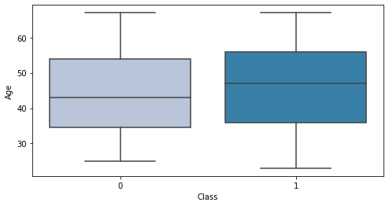

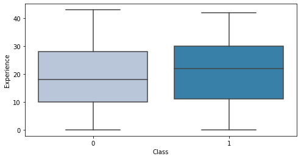

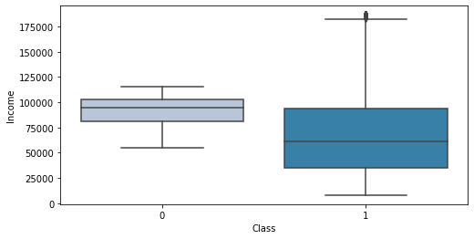

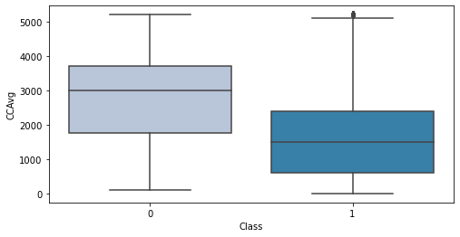

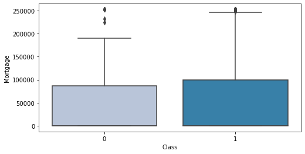

```python
# Box plot of Misclassified customers vs Correctly Classified Customers for numerical variables
cols = ['Age', 'Experience', 'Income','CCAvg', 'Mortgage']
for columns in cols:
    misc(columns)
```

### Observations

On average, a correctly classified customer (Positive and Negative) is around 47 years of age with about 22 years of experience. This customer earns slightly above 60,000 dollars and spends about 1,500 dollars on credit card bills monthly. They spend more on Mortgage than the misclassified customers.

### 2.9 Recommendations and Conclusions

Our final decision tree model provided us with the best recall score which is the important metric in evaluating this particular classification problem as earlier explained. As such, we will go ahead and recommend this model to AllLife Bank's Marketing team as a basis for targetting personal loan customers.

The most significant features when deciding on which customers to target are: Income, CCAvg, Family_3, Family_4, Education_2, Education_3. Using this, AllLife Bank can build a customer profile of customers who are most likely to accept the loan offer. This profile could look like this:

A personal loan customer on average earns about 148,000 dollars annually and spends about 3,900 dollars on credit cards bills monthly. These customers have a family size of 3 or 4 and are most likely to have achieved graduate or advanced levels of education.

These are affluent and highly educated customers with large families. This segment represents a small percentage of their customer base but can be worth as much as 80% of the revenue brought in from loan interests. There is therefore a huge incentive for the bank in attracting customers of this nature. A major strategy AllLife's marketing team could employ is Relationship Management. These types of customers tend to require personalized relationships with the bank. They want time to be taken out to understand their peculiar needs, wants, preferences and behavior and also seek real tangible value.

A way to do this while also incentivizing the customer to purchase a loan is by employing loyalty programs that reward customers for actively engaging with and using the bank. These rewards could come in the form of reduced loan and mortgage interest rates, and even slightly increased interest rates on CD and savings accounts. The way it could work would be that Customers would have to enroll in specific loyalty programs to qualify and have to be in the most active customers. This works because it costs little to initiate and it offers the customer real tangible value

AllLife Bank can differentiate themselves significantly by employing this model. By knowing which customers to target, the bank drastically reduces the cost of acquisition. By also understanding the core needs of these customers, they stand a very good chance in retaining these customers and possibly pushing more products like their CD and Securities accounts over time.